# Lab 1

Author

Melissa LaMette

## Packages

```python
from collections.abc import Sequence
import pandas as pd
from plotnine import ggplot, geom_point, aes, geom_boxplot, geom_text, xlim, ylim, ggtitle, labels, xlab, ylab,scale_x_continuous, scale_x_log10
from plotnine import *
```

# Data

```python
q1 = pd.read_csv('q1data.csv')
q2 = pd.read_csv('q2data.csv')
q3 = pd.read_csv('q3data.csv')
```

```python
## income, life_exp, population, year, country, four_regions, six_regions, eight_regions, world_bank_regions
q1 = q1.dropna()
q1
```

|  | income | life_exp | population | year | country | four_regions | six_regions | eight_regions | world_bank_region |
| --- | --- | --- | --- | --- | --- | --- | --- | --- | --- |
| 0 | 1910.0 | 61.0 | 29200000.0 | 2010 | Afghanistan | asia | south_asia | asia_west | South Asia |
| 1 | 11100.0 | 78.1 | 2950000.0 | 2010 | Albania | europe | europe_central_asia | europe_east | Europe & Central Asia |
| 2 | 11100.0 | 74.7 | 36000000.0 | 2010 | Algeria | africa | middle_east_north_africa | africa_north | Middle East & North Africa |
| 3 | 46900.0 | 81.9 | 84500.0 | 2010 | Andorra | europe | europe_central_asia | europe_west | Europe & Central Asia |
| 4 | 7680.0 | 60.8 | 23400000.0 | 2010 | Angola | africa | sub_saharan_africa | africa_sub_saharan | Sub-Saharan Africa |
| ... | ... | ... | ... | ... | ... | ... | ... | ... | ... |
| 192 | 20400.0 | 75.4 | 28400000.0 | 2010 | Venezuela | americas | america | america_south | Latin America & Caribbean |
| 193 | 5350.0 | 73.3 | 88000000.0 | 2010 | Vietnam | asia | east_asia_pacific | east_asia_pacific | East Asia & Pacific |
| 194 | 4700.0 | 67.8 | 23200000.0 | 2010 | Yemen | asia | middle_east_north_africa | asia_west | Middle East & North Africa |
| 195 | 3200.0 | 57.5 | 13600000.0 | 2010 | Zambia | africa | sub_saharan_africa | africa_sub_saharan | Sub-Saharan Africa |
| 196 | 2560.0 | 54.4 | 12700000.0 | 2010 | Zimbabwe | africa | sub_saharan_africa | africa_sub_saharan | Sub-Saharan Africa |

191 rows × 9 columns

```python
q3 = q3.dropna()
```

```python
df1 = pd.DataFrame(data=q1)
df2 = pd.DataFrame(data=q2)
df3 = pd.DataFrame(data=q3)
```

```python
df1 = df1.dropna()
df2 = df2.dropna()
df3 = df3.dropna()
```

```python
df1.dtypes
```

```
income               float64
life_exp             float64
population           float64
year                   int64
country               object
four_regions          object
six_regions           object
eight_regions         object
world_bank_region     object
dtype: object
```

```python
df2.dtypes
```

```
imports              float64
exports              float64
energy                object
year                   int64
country               object
four_regions          object
six_regions           object
eight_regions         object
world_bank_region     object
dtype: object
```

```python
df3.dtypes
```

```
internet_users       float64
gdp                  float64
income               float64
year                   int64
country               object
four_regions          object
six_regions           object
eight_regions         object
world_bank_region     object
dtype: object
```

```python
#x = df1['income']
#y = df1['life_exp']
#s = df1['population']
#b = df1['country']
#c = df1['four_regions']
#years = "years"
```

```python
df1
```

|  | income | life_exp | population | year | country | four_regions | six_regions | eight_regions | world_bank_region |
| --- | --- | --- | --- | --- | --- | --- | --- | --- | --- |
| 0 | 1910.0 | 61.0 | 29200000.0 | 2010 | Afghanistan | asia | south_asia | asia_west | South Asia |
| 1 | 11100.0 | 78.1 | 2950000.0 | 2010 | Albania | europe | europe_central_asia | europe_east | Europe & Central Asia |
| 2 | 11100.0 | 74.7 | 36000000.0 | 2010 | Algeria | africa | middle_east_north_africa | africa_north | Middle East & North Africa |
| 3 | 46900.0 | 81.9 | 84500.0 | 2010 | Andorra | europe | europe_central_asia | europe_west | Europe & Central Asia |
| 4 | 7680.0 | 60.8 | 23400000.0 | 2010 | Angola | africa | sub_saharan_africa | africa_sub_saharan | Sub-Saharan Africa |
| ... | ... | ... | ... | ... | ... | ... | ... | ... | ... |
| 192 | 20400.0 | 75.4 | 28400000.0 | 2010 | Venezuela | americas | america | america_south | Latin America & Caribbean |
| 193 | 5350.0 | 73.3 | 88000000.0 | 2010 | Vietnam | asia | east_asia_pacific | east_asia_pacific | East Asia & Pacific |
| 194 | 4700.0 | 67.8 | 23200000.0 | 2010 | Yemen | asia | middle_east_north_africa | asia_west | Middle East & North Africa |
| 195 | 3200.0 | 57.5 | 13600000.0 | 2010 | Zambia | africa | sub_saharan_africa | africa_sub_saharan | Sub-Saharan Africa |
| 196 | 2560.0 | 54.4 | 12700000.0 | 2010 | Zimbabwe | africa | sub_saharan_africa | africa_sub_saharan | Sub-Saharan Africa |

191 rows × 9 columns

```python
custom_y_labels = [20, 30, 40, 50, 60, 70, 80, 90]
```

```python
custom_top_x_labels = ["INCOME LEVEL 1", "LEVEL 2", "LEVEL 3", "LEVEL 4"]
custom_x_labels = [500, 1000, 2000, 4000, 8000, 16000, 32000, 64000]
size_scale_factor = 200000
```

# Task 1

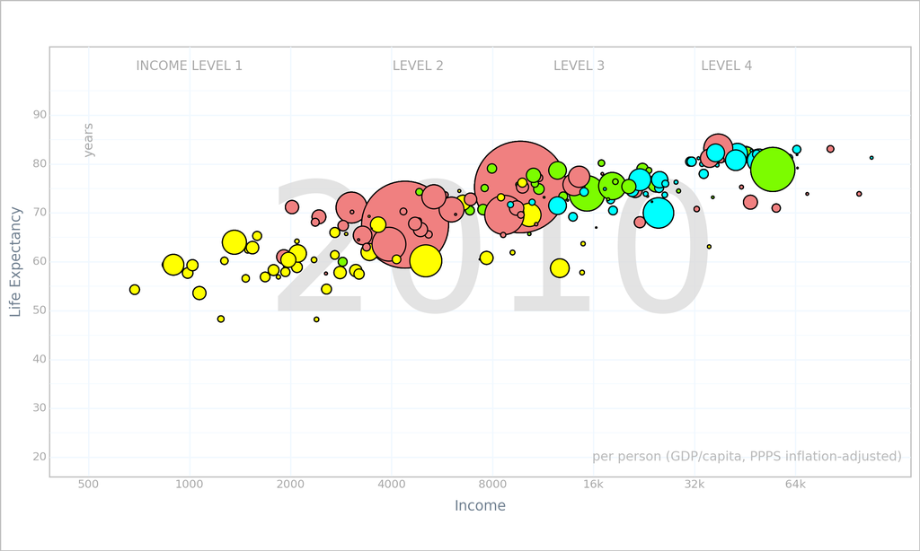

```
<Figure Size: (1200 x 720)>
```

```python
(ggplot(df1, aes (x = 'income', y = 'life_exp', size ='population', fill = "four_regions"))
+ annotate("text", x = 8000, y = 60, label = '2010', size = 140, alpha = 0.8, color = "gainsboro")
+ annotate("text", x = 46000, y= 20, label = 'per person (GDP/capita, PPPS inflation-adjusted)', size = 10, alpha = 0.8, color = "darkgrey")
+ annotate ("text",label= 'years', x=500, y=85, size = 10, color = "darkgrey", angle = "vertical")
 + annotate("text", label = 'INCOME LEVEL 1', x= 1000,y = 100, size = 10, color = "darkgrey")
 + annotate("text", label = 'LEVEL 2', x= 4800,y = 100, size = 10, color = "darkgrey")
 + annotate("text", label = 'LEVEL 3', x= 14500,y = 100, size = 10, color = "darkgrey")
 + annotate("text", label = 'LEVEL 4', x= 40000,y = 100, size = 10, color = "darkgrey")
 + geom_point()
 + geom_point()
 + geom_point()
 + geom_point()
 + scale_size_continuous(range = (0,40))
 + scale_fill_manual(values = ['yellow','lawngreen','lightcoral','cyan'])
+ xlab("Income") + ylab("Life Expectancy") + xlim(0,64000) +ylim(0,120)
+ scale_x_continuous(
        trans='log2',
        breaks=[500, 1000, 2000, 4000, 8000, 16000, 32000, 64000],
        labels = ["500","1000","2000","4000","8000","16k","32k","64k"],
    )
+ scale_y_continuous(limits=(20,100), breaks= range(20,100,10)
    )
+ theme(
    rect = element_rect(fill = "white", color = "silver", size = 1
    ),
    legend_position = "none",
        axis_line= element_line(size = .5),
        axis_line_x= element_line(color = "silver" ),
        axis_line_y= element_line(color = "silver"),
        axis_text=element_text(margin={'t': 5, 'r': 5}),
    axis_text_x= element_text(color= "darkgrey"),
    axis_text_y= element_text(color= "darkgrey"),
    axis_ticks_length=0, axis_title=element_text(),
    axis_title_x=element_text(color="slategrey"),
    axis_title_y=element_text(color="slategrey"),
panel_grid= element_line(color = "aliceblue"),panel_ontop=False,

    dpi=120,
    figure_size=(10, 6),
    aspect_ratio=1/2
)
    )
```

# New Geometry 1

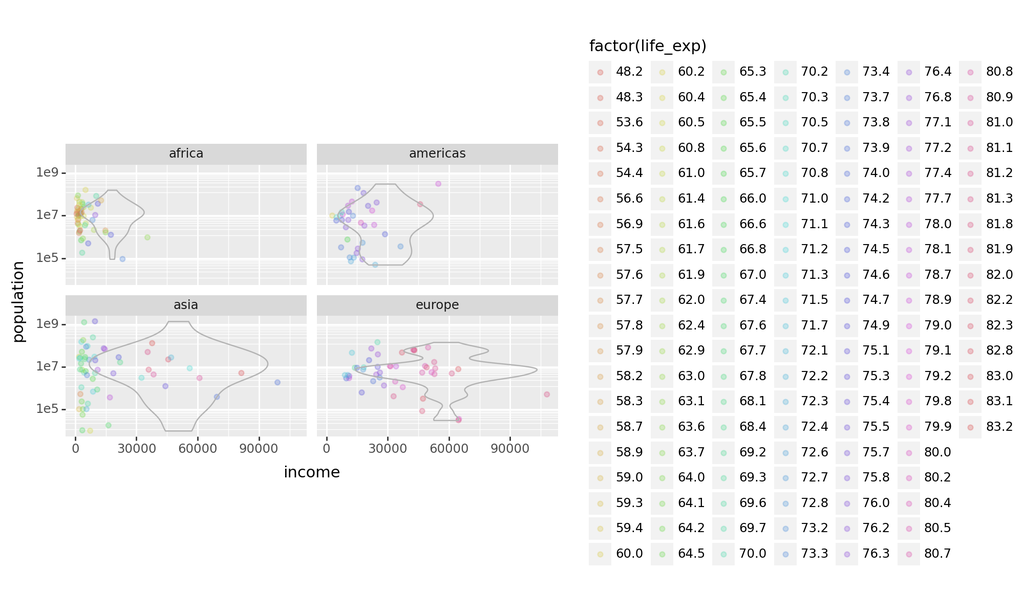

```
<Figure Size: (1000 x 600)>
```

```python
(ggplot(data=df1, mapping=aes(x='income', y='population', color ='factor(life_exp)'))
+ geom_jitter(alpha=0.3)
+ geom_violin(alpha=0, color="0.7")
+ scale_y_log10()
+ facet_wrap('four_regions')
+ theme(figure_size=(10, 6),
    aspect_ratio=1/2    )
)
```

This geometry is not the best representation of this data. Although it includes all four variables, it doesn’t convey the same story as clearly as the bubble graph. It takes one a second to understand how the violin shape is created with the x and y axis. I think the life_exp bubbles and it’s relationship with the other variables can be a little confusing as well.

# Task 2

```python
## imports, exports, energy, year, country, four_regions, six_regions, eight_regions, world_bank_regions
q2 = q2.dropna()
q2
```

|  | imports | exports | energy | year | country | four_regions | six_regions | eight_regions | world_bank_region |
| --- | --- | --- | --- | --- | --- | --- | --- | --- | --- |
| 1 | 36.7 | 11.5 | 427 | 1997 | Albania | europe | europe_central_asia | europe_east | Europe & Central Asia |
| 2 | 22.5 | 22.6 | 825 | 1997 | Algeria | africa | middle_east_north_africa | africa_north | Middle East & North Africa |
| 6 | 12.9 | 10.4 | 1660 | 1997 | Argentina | americas | america | america_south | Latin America & Caribbean |
| 7 | 52.8 | 19.0 | 610 | 1997 | Armenia | europe | europe_central_asia | europe_east | Europe & Central Asia |
| 9 | 20.5 | 19.6 | 5550 | 1997 | Australia | asia | east_asia_pacific | east_asia_pacific | East Asia & Pacific |
| ... | ... | ... | ... | ... | ... | ... | ... | ... | ... |
| 198 | 22.9 | 22.6 | 2080 | 1997 | Uzbekistan | asia | europe_central_asia | asia_west | Europe & Central Asia |
| 200 | 22.7 | 20.9 | 2250 | 1997 | Venezuela | americas | america | america_south | Latin America & Caribbean |
| 201 | 52.2 | 44.8 | 340 | 1997 | Vietnam | asia | east_asia_pacific | east_asia_pacific | East Asia & Pacific |
| 204 | 31.6 | 24.6 | 617 | 1997 | Zambia | africa | sub_saharan_africa | africa_sub_saharan | Sub-Saharan Africa |
| 205 | 45.1 | 43.4 | 845 | 1997 | Zimbabwe | africa | sub_saharan_africa | africa_sub_saharan | Sub-Saharan Africa |

127 rows × 9 columns

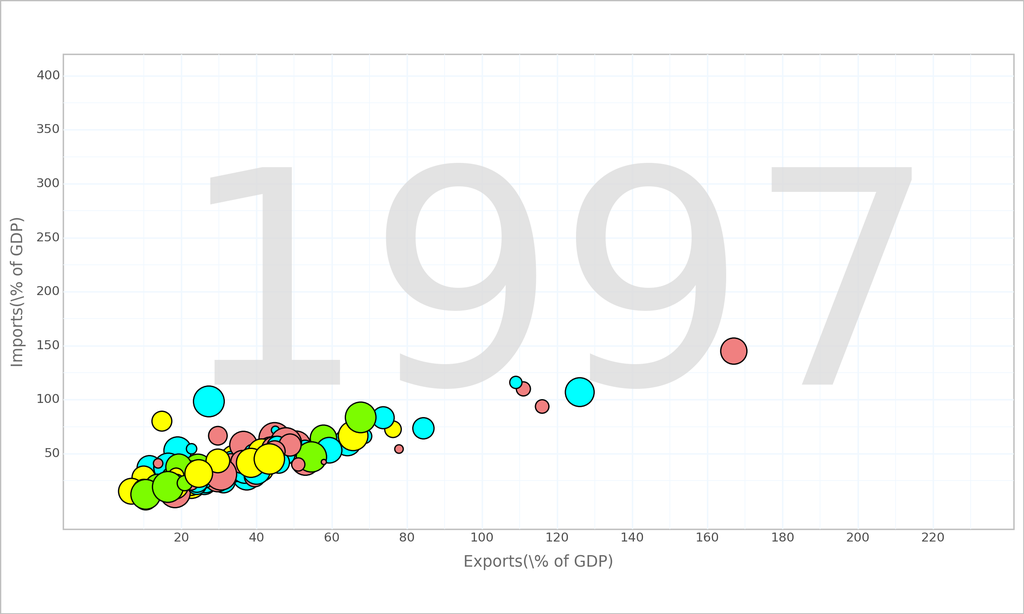

```
<Figure Size: (1200 x 720)>
```

```python
(ggplot(df2, aes (x = 'exports', y = 'imports', size ='energy', fill = "four_regions"))
+ annotate("text", x = 120, y = 190, label = '1997', size = 210, alpha = 0.8, color = "gainsboro")
 + geom_point()
 + xlab("Exports(\% of GDP)") + ylab("Imports(\% of GDP)")
 + scale_size_discrete(range = (0,12))
 + scale_fill_manual(values = ['yellow','lawngreen','lightcoral','cyan'])
 + scale_x_continuous(limits=(0,230), breaks= range(20,230,20)
    #trans='log10',
    #breaks=[20, 40, 60, 80, 100, 120, 140, 160, 180, 200, 220],
    #labels=["20", "40", "60", "80", "100", "120", "140", "160", "180", "200", "220"]
)
 + scale_y_continuous(limits=(0,400), breaks= range(50,450,50))
 + theme(legend_position = "none",
         axis_title_x=element_text(color="dimgrey"),
        axis_title_y=element_text(color="dimgrey"),
         axis_ticks_length=0,
         rect = element_rect(fill = "white", color = "silver", size = 1),
        panel_grid= element_line(color = "aliceblue"),panel_ontop=False,
         dpi=120,
    figure_size=(10, 6),
    aspect_ratio=1/2
    ))
```

# New Geometry 2

```python
df2 = df2.dropna()
```

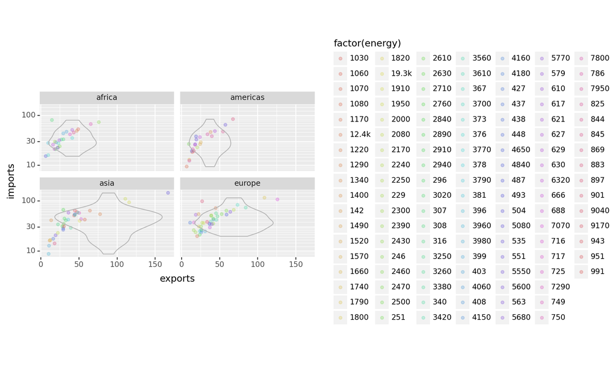

```
<Figure Size: (1000 x 600)>
```

```python
(ggplot(data=df2, mapping=aes(x='exports', y='imports', color ='factor(energy)'))
+ geom_jitter(alpha=0.3)
+ geom_violin(alpha=0, color="0.7")
+ scale_y_log10()
+ facet_wrap('four_regions')
+ theme(figure_size=(10, 6),
    aspect_ratio=1/2    )
)
```

Similar to the my previous geometry is not the best representation of this data. Although it includes all four variables, it doesn’t convey the same story as clearly as the bubble graph. This one is slightly easier to read because you can see a linear relationship the bubbles seem to be forming. It could be easier to conclude why the energy bubbles seem to cluster together and form a sort of line. However, it is still difficult to understand the data with this geomtry.

# Task 3

```python
## internet_users, gdp, income, year,   country,    four_regions,   six_regions,    eight_regions,  world_bank_region
q3
```

|  | internet_users | gdp | income | year | country | four_regions | six_regions | eight_regions | world_bank_region |
| --- | --- | --- | --- | --- | --- | --- | --- | --- | --- |
| 0 | 0.00456 | 330.0 | 1190.0 | 2001 | Afghanistan | asia | south_asia | asia_west | South Asia |
| 1 | 0.39000 | 2570.0 | 6780.0 | 2001 | Albania | europe | europe_central_asia | europe_east | Europe & Central Asia |
| 2 | 1.59000 | 3770.0 | 9230.0 | 2001 | Algeria | africa | middle_east_north_africa | africa_north | Middle East & North Africa |
| 4 | 11.30000 | 42600.0 | 35600.0 | 2001 | Andorra | europe | europe_central_asia | europe_west | Europe & Central Asia |
| 5 | 0.27000 | 2440.0 | 2900.0 | 2001 | Angola | africa | sub_saharan_africa | africa_sub_saharan | Sub-Saharan Africa |
| ... | ... | ... | ... | ... | ... | ... | ... | ... | ... |
| 209 | 4.91000 | 10800.0 | 14800.0 | 2001 | Venezuela | americas | america | america_south | Latin America & Caribbean |
| 210 | 1.85000 | 847.0 | 3270.0 | 2001 | Vietnam | asia | east_asia_pacific | east_asia_pacific | East Asia & Pacific |
| 212 | 0.51900 | 1190.0 | 4940.0 | 2001 | Yemen | asia | middle_east_north_africa | asia_west | Middle East & North Africa |
| 213 | 0.47800 | 991.0 | 2080.0 | 2001 | Zambia | africa | sub_saharan_africa | africa_sub_saharan | Sub-Saharan Africa |
| 214 | 1.10000 | 1330.0 | 3190.0 | 2001 | Zimbabwe | africa | sub_saharan_africa | africa_sub_saharan | Sub-Saharan Africa |

181 rows × 9 columns

```python
c_lables = [200,500,1000,2000,5000,10000,20000,50000,100000],["200","500","1000","2000","5000","10k","20k","50k","100k"]
```

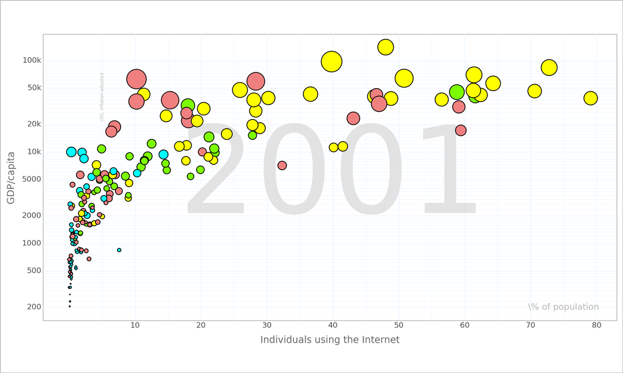

```
<Figure Size: (1200 x 720)>
```

```python
(ggplot(df3, aes (x = 'internet_users', y = 'gdp', size ='income', fill = "four_regions"))
+ annotate("text", x = 40, y = 5000, label = '2001', size = 140, alpha = 0.8, color = "gainsboro")
+ annotate("text", x = 75, y = 200, label = '\% of population', size = 10, alpha = 0.8, color = "darkgray")
 + annotate("text", x = 5, y = 40000, label = 'USS, inflation-adjusted', size = 5, alpha = 0.8, color = "darkgray", angle = "vertical")
 + geom_point()
 + xlab("Individuals using the Internet") + ylab("GDP/capita")
 + scale_size_continuous(range = (0,13))
 + scale_fill_manual(values = ['cyan','lawngreen','lightcoral','yellow'])
 + scale_x_continuous(
        breaks= range(10,130,10)
    )
 + scale_y_continuous(
    trans = 'log10',
    breaks=[200,500,1000,2000,5000,10000,20000,50000,100000],
    labels = ["200","500","1000","2000","5000","10k","20k","50k","100k"])
 + theme(legend_position = "none",
         axis_title_x=element_text(color="dimgrey"),
        axis_title_y=element_text(color="dimgrey"),
         axis_ticks_length=0,
         rect = element_rect(fill = "white", color = "silver", size = 1),
        panel_grid= element_line(color = "aliceblue"),panel_ontop=False,
         dpi=120,
    figure_size=(10, 6),
    aspect_ratio=1/2
    ))
```

# New Geometry 3

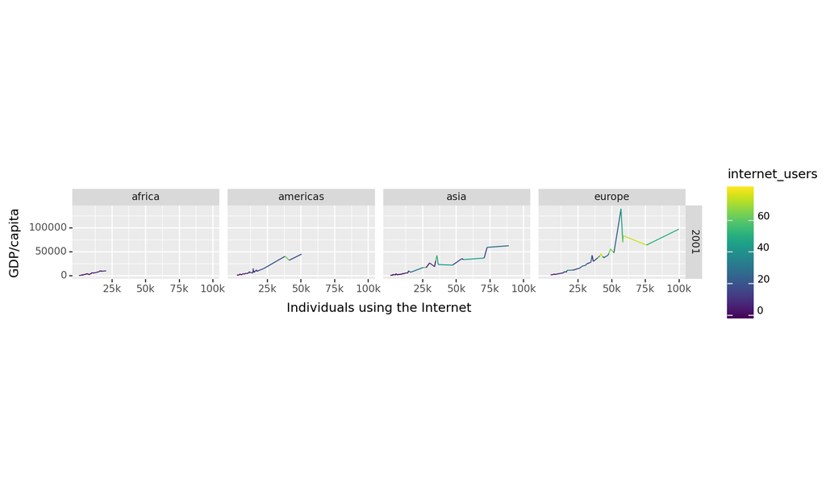

```
<Figure Size: (1000 x 600)>
```

```python
(ggplot(data=df3,
           mapping=aes(x='income',
                          y='gdp',
                          color='internet_users'))
    + geom_line()
    + scale_x_continuous(
    breaks=[25000,50000,75000,100000],
    labels = ["25k","50k","75k","100k"])
    + xlab("Individuals using the Internet") + ylab("GDP/capita")
    #+ facet_wrap("four_regions")
    + facet_grid("year~four_regions")
    + theme(figure_size=(10, 6),
    aspect_ratio=1/2  )
)
```

This is not a good representation of the data all. It is not very compelling. I do not think it is specific enough. It makes Africa look like there is no data. I will say it shows the differenc between income and gdp very well. However, it still does not convey the same story as the bubble graph.